# Tutorial 2: Lasso for causal inference

Madina Kurmangaliyeva

# Preliminaries

```r
req_packages <- c(
  "glmnet",
  "hdm",
  "tidyverse",
  "broom"
)

if (!require("pacman")) install.packages("pacman")
pacman::p_load(req_packages, character.only = TRUE)
```

# Post-regularization inference: the wrong way

Let’s create a matrix populated by random standard normal observations ~N(0,1). The variables we created are named from `V1` to `V100`.

```r
set.seed(9204825)
P <- 100
N <- 100
simulated <- matrix(
  rnorm(n = N*P),
  nrow = N,
  ncol = P) %>%
  as.data.frame()
simulated %>% head()
```

|  | V1 | V2 | V3 | V4 | V5 | V6 | V7 | V8 | V9 | V10 | V11 | V12 | V13 | V14 | V15 | V16 | V17 | V18 | V19 | V20 | V21 | V22 | V23 | V24 | V25 | V26 | V27 | V28 | V29 | … |
| --- | --- | --- | --- | --- | --- | --- | --- | --- | --- | --- | --- | --- | --- | --- | --- | --- | --- | --- | --- | --- | --- | --- | --- | --- | --- | --- | --- | --- | --- | --- |
| 1 | 0.9309176 | -0.79118435 | 1.17874283 | -1.38356222 | 0.2503239 | 0.64940296 | 1.20420144 | -0.97650976 | 0.6035195 | 1.79630004 | -0.8473677 | 0.6578108 | 0.45190123 | 1.26801981 | 3.31430450 | -0.6283923 | 1.1302376 | 1.34356613 | -0.29925511 | -0.6558259 | 1.6909958 | 0.4845307 | -0.02640991 | -2.19027308 | 0.20159953 | -0.3064309 | 0.08535396 | -0.48591588 | -0.83481260 | … |
| 2 | 0.1321005 | -0.03430753 | 0.76782502 | 0.19449651 | 0.3687262 | 0.16919356 | 1.93642341 | 0.11376227 | 0.9343755 | -0.09427769 | -0.2713667 | -0.1476679 | -0.21877121 | -0.56573627 | 0.37801485 | 0.9436486 | 0.1438111 | -0.27010907 | -2.81379067 | 3.1651554 | -0.2170069 | -0.1327590 | 0.88483813 | -0.96442511 | -0.18235274 | -1.5004233 | 0.42229012 | 0.07260879 | 0.34116814 | … |
| 3 | 0.8054129 | 0.53303168 | 0.52875635 | -0.51105112 | -0.9589423 | 1.25317098 | -0.34352991 | 0.17372746 | -0.6294532 | 1.30261524 | 0.9720013 | -0.8262020 | 1.05944379 | 0.57428063 | -0.35722622 | -1.0243094 | -1.1149867 | 0.03258382 | 1.27960392 | 0.5476651 | -1.7972624 | 0.1861519 | 0.21881215 | -0.49049546 | 1.10982646 | -0.3730869 | 0.58617075 | 0.86092151 | -0.29142184 | … |
| 4 | -1.2247856 | -1.44895135 | 0.01622522 | 0.24628801 | 0.1721829 | -0.05272934 | -0.25670086 | 0.75302272 | 0.4848095 | 2.12684188 | -0.6445785 | -1.5806370 | -0.15248977 | -1.02125162 | 1.43497456 | -1.3743005 | -2.0819628 | -0.85154393 | 0.49238470 | 2.3193723 | 0.6757156 | 1.7066794 | 0.43106659 | 0.02374249 | -0.07095057 | -0.6116963 | -0.59544562 | 0.33135713 | 1.19794258 | … |
| 5 | -0.1366374 | 1.58623172 | -1.03040543 | 0.91620249 | -1.8030336 | -0.49466583 | -0.56905721 | -0.04969863 | -1.2140716 | -0.30958057 | 0.7813561 | -0.1632470 | 0.05729795 | 0.49013504 | 0.09694719 | -1.3125524 | -0.7990142 | 0.08478577 | -3.00101191 | 0.9437138 | -0.4177442 | -1.4091401 | 0.69013309 | 0.82442810 | 0.80802489 | -1.0041926 | -0.42973098 | 0.22111983 | -1.50347673 | … |
| 6 | -0.1154206 | -0.26673358 | 2.37170054 | -0.07140703 | -0.1229454 | 0.01829595 | -0.04628211 | -1.10604771 | -1.9996381 | -0.63206459 | 0.8243126 | 2.4712457 | -0.66103287 | -0.01450291 | -0.26448196 | 1.0129866 | -0.4255160 | 0.80914742 | -0.07941003 | 1.6543699 | 1.5303247 | 1.5588136 | 1.30735157 | 1.16943304 | 1.46652716 | 0.4956171 | -0.40719728 | 0.77806644 | -0.02558162 | … |

Now, we will simulate a target variable `y` which depends on the first nine variables `V1` to `V9`, and also it depends on the treatment variable `d`. The treatment effect is 1. At the same time, treatment depends on the first three variables `V1` to `V3`.

```r
set.seed(25)

simulated <- simulated %>%
  mutate(
    d = V1 + V2 + V3 + 0.2*rnorm(N),
    y = 1*d + 10*V1 + 10*V2 + 10*V3 +
      10*V4 + 10*V5 + 10*V6 +
      10*V7 + 10*V8 + 10*V9 + rnorm(N)
    ) %>%
  select(y, d, everything())

simulated %>%  head()
```

|  | y | d | V1 | V2 | V3 | V4 | V5 | V6 | V7 | V8 | V9 | V10 | V11 | V12 | V13 | V14 | V15 | V16 | V17 | V18 | V19 | V20 | V21 | V22 | V23 | V24 | V25 | V26 | V27 | … |
| --- | --- | --- | --- | --- | --- | --- | --- | --- | --- | --- | --- | --- | --- | --- | --- | --- | --- | --- | --- | --- | --- | --- | --- | --- | --- | --- | --- | --- | --- | --- |
| 1 | 17.000453 | 1.2761093 | 0.9309176 | -0.79118435 | 1.17874283 | -1.38356222 | 0.2503239 | 0.64940296 | 1.20420144 | -0.97650976 | 0.6035195 | 1.79630004 | -0.8473677 | 0.6578108 | 0.45190123 | 1.26801981 | 3.31430450 | -0.6283923 | 1.1302376 | 1.34356613 | -0.29925511 | -0.6558259 | 1.6909958 | 0.4845307 | -0.02640991 | -2.19027308 | 0.20159953 | -0.3064309 | 0.08535396 | … |
| 2 | 44.732269 | 0.6572998 | 0.1321005 | -0.03430753 | 0.76782502 | 0.19449651 | 0.3687262 | 0.16919356 | 1.93642341 | 0.11376227 | 0.9343755 | -0.09427769 | -0.2713667 | -0.1476679 | -0.21877121 | -0.56573627 | 0.37801485 | 0.9436486 | 0.1438111 | -0.27010907 | -2.81379067 | 3.1651554 | -0.2170069 | -0.1327590 | 0.88483813 | -0.96442511 | -0.18235274 | -1.5004233 | 0.42229012 | … |
| 3 | 9.796992 | 1.6365394 | 0.8054129 | 0.53303168 | 0.52875635 | -0.51105112 | -0.9589423 | 1.25317098 | -0.34352991 | 0.17372746 | -0.6294532 | 1.30261524 | 0.9720013 | -0.8262020 | 1.05944379 | 0.57428063 | -0.35722622 | -1.0243094 | -1.1149867 | 0.03258382 | 1.27960392 | 0.5476651 | -1.7972624 | 0.1861519 | 0.21881215 | -0.49049546 | 1.10982646 | -0.3730869 | 0.58617075 | … |
| 4 | -16.197368 | -2.5932054 | -1.2247856 | -1.44895135 | 0.01622522 | 0.24628801 | 0.1721829 | -0.05272934 | -0.25670086 | 0.75302272 | 0.4848095 | 2.12684188 | -0.6445785 | -1.5806370 | -0.15248977 | -1.02125162 | 1.43497456 | -1.3743005 | -2.0819628 | -0.85154393 | 0.49238470 | 2.3193723 | 0.6757156 | 1.7066794 | 0.43106659 | 0.02374249 | -0.07095057 | -0.6116963 | -0.59544562 | … |
| 5 | -27.060867 | 0.1191629 | -0.1366374 | 1.58623172 | -1.03040543 | 0.91620249 | -1.8030336 | -0.49466583 | -0.56905721 | -0.04969863 | -1.2140716 | -0.30958057 | 0.7813561 | -0.1632470 | 0.05729795 | 0.49013504 | 0.09694719 | -1.3125524 | -0.7990142 | 0.08478577 | -3.00101191 | 0.9437138 | -0.4177442 | -1.4091401 | 0.69013309 | 0.82442810 | 0.80802489 | -1.0041926 | -0.42973098 | … |
| 6 | -12.179247 | 1.9004397 | -0.1154206 | -0.26673358 | 2.37170054 | -0.07140703 | -0.1229454 | 0.01829595 | -0.04628211 | -1.10604771 | -1.9996381 | -0.63206459 | 0.8243126 | 2.4712457 | -0.66103287 | -0.01450291 | -0.26448196 | 1.0129866 | -0.4255160 | 0.80914742 | -0.07941003 | 1.6543699 | 1.5303247 | 1.5588136 | 1.30735157 | 1.16943304 | 1.46652716 | 0.4956171 | -0.40719728 | … |

You ex-ante do not know which variables are important for `d` or `y`, but you are interested in the impact of `d` on `y`.

**Exercise:** Let’s try to run a regression with all the controls:

```r
# Put your code here
```

| term | estimate | std.error | statistic | p.value |
| --- | --- | --- | --- | --- |
| (Intercept) | 0.43613177 | NaN | NaN | NaN |
| d | 11.09390923 | NaN | NaN | NaN |
| V1 | 2.03753416 | NaN | NaN | NaN |
| V2 | -0.16692722 | NaN | NaN | NaN |
| V3 | -1.05592953 | NaN | NaN | NaN |
| V4 | 12.95763106 | NaN | NaN | NaN |
| V5 | 6.83953078 | NaN | NaN | NaN |
| V6 | 8.49600886 | NaN | NaN | NaN |
| V7 | 10.18013296 | NaN | NaN | NaN |
| V8 | 10.99195188 | NaN | NaN | NaN |

[output cut: 90 more lines]

Question: What is hapenning with the estimates for standard errors? What is tge estimate of the treatment effect?

## Naive Lasso

Now let’s try to use Lasso and cross-validation to select variables that explain y.

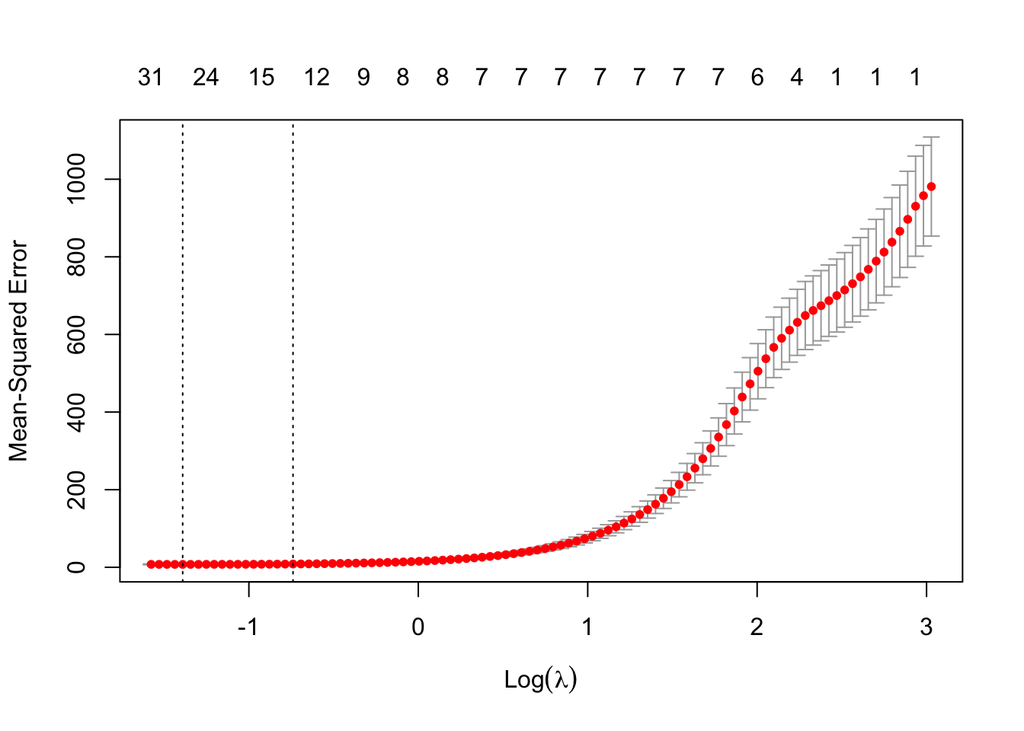

```r
set.seed(2385)
X <- simulated %>%  select(-y)  %>%  as.matrix()
cv_Lasso <- cv.glmnet(X, simulated$y, alpha = 1)
plot(cv_Lasso)
```

Lasso chose more than 25 predictors. It is more than ten variables in the true model, but it is still less than 101 variables we started with.

Now using the knowledge from the previous tutorial: 1) We extract the best lambda from `cv_Lasso` 2) Run Lasso regression on `simulated` 3) Get the coefficients at the best lambda and filter only those coefficients that have non-zero values.

```r
bestlam <- cv_Lasso$lambda.min
Lasso_reg <- glmnet(X, simulated$y, alpha = 1)
Lasso_coefficients <- predict(Lasso_reg,  type = "coefficients", s = bestlam) %>%
  as.matrix() %>%
  as.data.frame() %>%
  mutate(coef_names = row.names(.)) %>%
  rename(coef = `1`) %>% filter(coef != 0)
```

Now let’s see whether `d` is among the chosen variables and if so, what its coefficient is.

```r
Lasso_coefficients
```

| coef | coef_names |
| --- | --- |
| 0.239691682 | (Intercept) |
| 10.642582974 | d |
| 0.234333622 | V1 |
| 0.441413466 | V2 |
| 9.678085935 | V4 |
| 9.434129933 | V5 |
| 9.593675914 | V6 |
| 9.713761174 | V7 |
| 9.148359756 | V8 |
| 9.313974769 | V9 |

[output cut: 18 more lines]

As you can see the coefficient in front of `d` is wrong. Why? Would running an OLS using the variables selected by Lasso + `d` help?

**Exercise:** Run an OLS with `y` as dependent variable, and `d` + all other variables that have been selected by Lasso (i.e., Lasso_coefficients):

```r
# Put your code here
```

| term | estimate | std.error | statistic | p.value |
| --- | --- | --- | --- | --- |
| (Intercept) | 0.379543911 | 0.2331980 | 1.62756069 | 1.079867e-01 |
| d | 10.359781299 | 0.1848966 | 56.03014327 | 3.977763e-61 |
| V1 | 0.857824048 | 0.2658346 | 3.22690885 | 1.884307e-03 |
| V2 | 0.900055190 | 0.2752596 | 3.26984085 | 1.652271e-03 |
| V4 | 9.695709706 | 0.2157801 | 44.93329891 | 2.043527e-54 |
| V5 | 9.622084731 | 0.2224915 | 43.24696984 | 2.912878e-53 |
| V6 | 9.706345159 | 0.1819885 | 53.33494639 | 1.274557e-59 |
| V7 | 9.944828303 | 0.2087201 | 47.64671787 | 3.434011e-56 |
| V8 | 9.296389277 | 0.2353644 | 39.49784980 | 1.536630e-50 |
| V9 | 9.525739432 | 0.2095010 | 45.46870232 | 8.962569e-55 |

[output cut: 18 more lines]

Even if we run a post-Lasso OLS regression, using only the variables chosen by Lasso, the coefficient in front of `d` (10.359) is still very different from the true treatment effect (1.000):

Questions: 1) Note, which important variable is missing? 2) Why is it missing? 3) What is wrong with Lasso?

## Create 100 simulated datasets

In order to study the property of the estimator in different random samples, let’s create a bigger simulation: one hundred datasets randomly generated from the same data-generating process

```r
set.seed(123)
nSim <- 100
simulated100 <-  matrix(
  rnorm(n = N*P*nSim),
  nrow = N*nSim,
  ncol = P) %>%
  as.data.frame() %>%
  mutate(
    d = V1 + V2 + V3 + 0.2*rnorm(N*nSim),
    y = 1*d + 10*V1 + 10*V2 + 10*V3 +
      10*V4 + 10*V5 + 10*V6 +
      10*V7 + 10*V8 + 10*V9 + rnorm(N*nSim),
    SimNumber = rep(c(1:nSim), each = N)
    ) %>%
  select(y, d, everything())

# Nest simulated datasets
simulated100 <- simulated100 %>%
  group_by(SimNumber) %>%
  nest()

simulated100 %>% head()
```

| SimNumber | data |
| --- | --- |
| 1 |  |
| 2 |  |
| 3 |  |
| 4 |  |
| 5 |  |
| 6 |  |

```r
simulated100$data[[1]] %>%  head()
```

| y | d | V1 | V2 | V3 | V4 | V5 | V6 | V7 | V8 | V9 | V10 | V11 | V12 | V13 | V14 | V15 | V16 | V17 | V18 | V19 | V20 | V21 | V22 | V23 | V24 | V25 | V26 | V27 | V28 | … |
| --- | --- | --- | --- | --- | --- | --- | --- | --- | --- | --- | --- | --- | --- | --- | --- | --- | --- | --- | --- | --- | --- | --- | --- | --- | --- | --- | --- | --- | --- | --- |
| 23.032492 | 0.7723387 | -0.56047565 | 2.3707252 | -0.8362967 | -0.19360641 | 0.48252737 | 0.2595897 | -0.38827164 | 0.4142726 | 0.7829594 | 0.57316537 | 0.26499342 | -1.6488988 | -1.3383826 | 1.2018445 | 1.4228523 | 0.8166259 | -2.3572118 | -1.49836931 | -1.1781172 | 1.3757760 | 0.2890801 | 1.0374009 | -0.3016608 | 1.2692379 | -1.8633436 | -0.69317476 | -1.0118493 | -0.31431669 | … |
| 2.242433 | -0.3465746 | -0.23017749 | -0.1668120 | -0.2205730 | 0.25814728 | 0.72136466 | 0.9175107 | 0.02735330 | -0.6409547 | -0.4238261 | 0.01831995 | 1.83074748 | 0.2651860 | -1.0363707 | -1.3359245 | -0.6841353 | 0.6814511 | -0.9064735 | 1.05899218 | 0.3688368 | -0.0179893 | -0.8181370 | -0.1751520 | -0.6680220 | -0.1950618 | 0.2014265 | 1.59798470 | -0.5261088 | 0.04859306 | … |
| -21.329876 | 0.2883600 | 1.55870831 | 0.9269614 | -2.1035148 | -0.53831257 | -0.50779230 | -0.7223183 | -0.27609180 | 0.2813767 | -0.8444830 | -0.02198239 | -0.05937826 | 0.2470021 | -0.8916490 | 2.1657476 | 0.7843555 | 1.4928247 | 0.2312451 | 1.09931205 | -1.0594447 | -1.1403292 | -1.5232732 | -0.5949550 | -1.0104516 | -0.8947428 | 0.6828644 | 0.67010041 | 0.7879997 | -0.11483829 | … |
| -43.047651 | -1.8718122 | 0.07050839 | -0.5681517 | -1.6678075 | -1.17906281 | -0.06470875 | -0.8082840 | -0.08668181 | -0.6938917 | 0.8761144 | -0.42779518 | -0.05320937 | 0.2928121 | 0.2346563 | 0.4688231 | 1.6400610 | -1.4570133 | -0.3402657 | 0.58004507 | 0.1059650 | -0.6909986 | -0.4288842 | 0.7507826 | -2.0754754 | -0.1528002 | 1.2222004 | 1.47802235 | 0.5029925 | -1.06929398 | … |
| 41.457330 | -0.6550738 | 0.12928774 | 0.2250901 | -1.0979629 | 0.90064742 | 1.30212117 | -0.1413520 | 2.14768996 | -0.3669018 | 1.1246952 | -0.47760501 | 0.43790418 | 0.1060545 | -0.1689831 | -1.0846425 | 1.3573333 | -0.4830195 | -0.1967164 | -0.08882226 | -1.5261744 | -0.7883074 | -0.8873405 | -1.2655594 | -0.1519789 | 0.6215942 | -1.4242794 | 0.14616790 | -1.4587302 | -0.58961906 | … |
| 13.844198 | 1.2106703 | 1.71506499 | 1.1319859 | -1.6656212 | -0.01624955 | -0.21863687 | 2.2570135 | -0.80974953 | -0.8488912 | -0.1765637 | 1.01762590 | 1.33744904 | -0.6322176 | -0.8155807 | 0.3263995 | -0.4401487 | 1.1000737 | -0.4102153 | -0.44714606 | -0.2907321 | -0.3704835 | -0.1810967 | 0.3575726 | 1.1917794 | 2.3095726 | -0.2090901 | -0.04590133 | -2.6910596 | -1.74139763 | … |

```r
simulated100$data[[1]] %>%  names()
```

```
##   [1] "y"    "d"    "V1"   "V2"   "V3"   "V4"   "V5"   "V6"   "V7"   "V8"
##  [11] "V9"   "V10"  "V11"  "V12"  "V13"  "V14"  "V15"  "V16"  "V17"  "V18"
##  [21] "V19"  "V20"  "V21"  "V22"  "V23"  "V24"  "V25"  "V26"  "V27"  "V28"
##  [31] "V29"  "V30"  "V31"  "V32"  "V33"  "V34"  "V35"  "V36"  "V37"  "V38"
##  [41] "V39"  "V40"  "V41"  "V42"  "V43"  "V44"  "V45"  "V46"  "V47"  "V48"
##  [51] "V49"  "V50"  "V51"  "V52"  "V53"  "V54"  "V55"  "V56"  "V57"  "V58"
##  [61] "V59"  "V60"  "V61"  "V62"  "V63"  "V64"  "V65"  "V66"  "V67"  "V68"
##  [71] "V69"  "V70"  "V71"  "V72"  "V73"  "V74"  "V75"  "V76"  "V77"  "V78"
##  [81] "V79"  "V80"  "V81"  "V82"  "V83"  "V84"  "V85"  "V86"  "V87"  "V88"
##  [91] "V89"  "V90"  "V91"  "V92"  "V93"  "V94"  "V95"  "V96"  "V97"  "V98"
## [101] "V99"  "V100"
```

### What if we knew the true functional form and run OLS?

If we knew the true functional form, we could estimate the treatment effect using OLS. We would make sure to include control variables from V1 to V9 in our regression.

Let’s run such an OLS with the true functional form on each simulated dataset:

1. Note that we first need to create a function, which we name `simulate_correctols()`, save it in the `functions` subfolder of the tutorials as `simulate_correctols.R`. We call the function with `source()`. `simulate_correctols()` takes only one argument as input – the dataframe – and returns back a row with the OLS estimates of the treatment effect. (See the code in `simulate_correctols.R`)
2. Finally, we apply that function on each random sample of the simulated data. We achieve it using `map_dfr()` function, instead of using a `for` loop.
1. The first argument in `map_dfr()` gives you the counter `.x` from `1` to the total number of simulations `nSim`. Remember that we can access any of the one hundred different simulations of a dataset, by subsetting it in this manner: `simulated100$data[[simulation_number]]`.
2. The last argument is the function that we want to run. In our case, it is `simulate_correctols()`, which we apply on the simulated data. Note, that the counter `.x` helps us access the corresponding simulation: `simulated100$data[[.x]]`

```r
set.seed(83)
source("./functions/simulate_correctols.R")
results_true <- map_dfr(.x = c(1:nSim), ~simulate_correctols(simulated100$data[[.x]]))
```

Let’s plot the results. I created a special function `plot_estimates_tut2()` for plotting the estimation results in this tutorial.

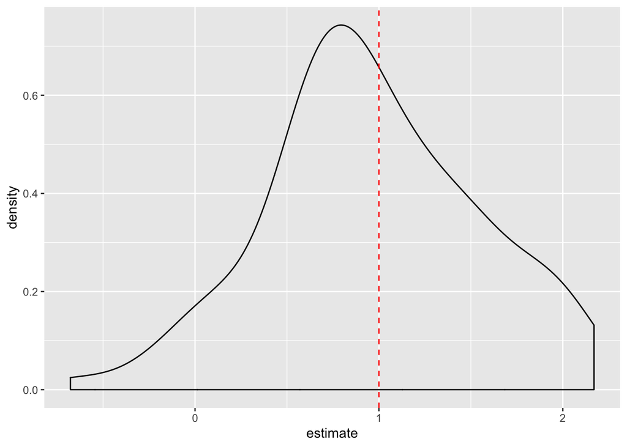

```r
# Plot the results
source("./functions/plot_estimates_tut2.R")
plot_estimates_tut2(results_true)
```

The dashed red line points to the true treatment effect.

```r
# Mean of the distribution
results_true %>% summarise(mean(estimate), sd(estimate))
```

| mean(estimate) | sd(estimate) |
| --- | --- |
| 0.9660863 | 0.5758438 |

## Distribution of the naive Lasso estimator

But, let’s see the distribution of coefficients in front of `d` using naive lasso on those 100 different samples of data by applying the naive lasso for each sample.

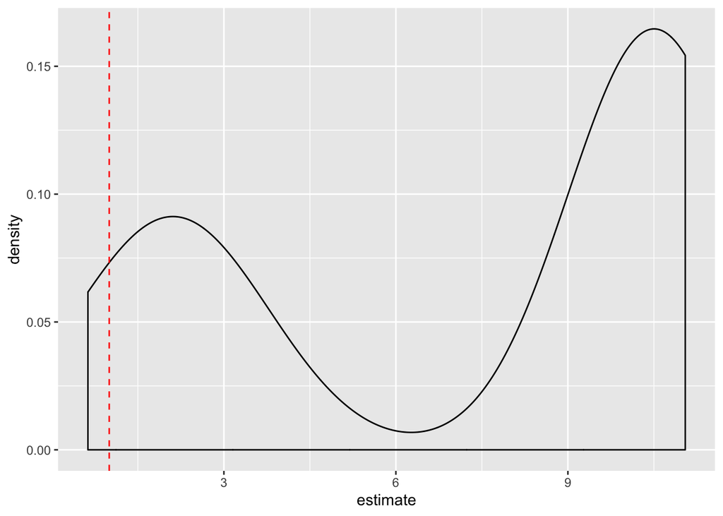

```r
source("./functions/simulate_naiveLasso.R")
set.seed(456)
results_naive <- map_dfr(.x = c(1:nSim), ~simulate_naiveLasso(data = simulated100$data[[.x]]))

# Plot the results
source("./functions/plot_estimates_tut2.R")
plot_estimates_tut2(results_naive)
```

As you can see, the distribution of estimates is centered around two numbers: it has a weird bump on the right tail (by now you should know why).

```r
# Mean of the distribution
results_naive %>% summarise(mean(estimate), sd(estimate))
```

| mean(estimate) | sd(estimate) |
| --- | --- |
| 7.309408 | 4.133064 |

## Why does naive Lasso fail to estimate the treatment effect?

1. The objective of Lasso is prediction not estimation
2. We selected the controls that best predict `y`, but we forgot about `d` and omitted-variables bias problem.

In the chunk code `get_Lasso_coefficients`, we see that `V3` was missing because `d` and `V3` were correlated and Lasso dropped `V3`. Its goal was prediction: `d` and `V3` were predicting `y` equivalently well, no need to keep both. While we wanted to keep `V3` because dropping would generate bias in estimating the treatment effect.

What can we do? Double Selection!

# Double selection (DS)

## Partialling out estimator

In order to understand DS approach for causal inference, we first need to take another look at the OLS.

Let us simulate simple data, where `d` is the variable of interest, `z` is an endogenous variable, and `y` is outcome, generated according the following data-generating process:

```r
set.seed(42)
partout_sim <- tibble(
  z = runif(n = 1000, min = 0, max = 5),
  d = 5*z + 2*rnorm(n = 1000) + rnorm(n = 1000),
  y = 10 + 2*d + 7*z + rnorm(n = 1000)
)

lm(y ~ d, data = partout_sim) %>%
  tidy()
```

| term | estimate | std.error | statistic | p.value |
| --- | --- | --- | --- | --- |
| (Intercept) | 11.545611 | 0.18331193 | 62.98341 | 0 |
| d | 3.275665 | 0.01273907 | 257.13539 | 0 |

Omitting `z` generates an omitted variable bias. The estimate of a coefficient corresponding to `d` is 3.3, while we know the true coefficient is 2.

```r
lm(y ~ d + z, data = partout_sim) %>%
  tidy()
```

| term | estimate | std.error | statistic | p.value |
| --- | --- | --- | --- | --- |
| (Intercept) | 9.920323 | 0.06380870 | 155.46976 | 0 |
| d | 1.998546 | 0.01492376 | 133.91702 | 0 |
| z | 7.030062 | 0.07874810 | 89.27278 | 0 |

When we include `z` as a control, the bias disappears.

**Exercise** Now, let’s partial out `z` from `d` and `y`. In other words, regress `d` on `z` to obtain residuals. Then, regress `y` on `z`. And then run the residuals of `y` on the residuals of `d`.

```r
# Put your answer here.

d_no_z <- lm(d ~ z, data = partout_sim) %>% resid()
# 2) y_no_z <- ...
# 3) regress y_no_z on x_no_z
```

| term | estimate | std.error | statistic | p.value |
| --- | --- | --- | --- | --- |
| (Intercept) | -9.841566e-17 | 0.03264523 | -3.014702e-15 | 1 |
| d_no_z | 1.998546e+00 | 0.01491628 | 1.339842e+02 | 0 |

What is the coefficient in from of `d_no_z`? Is it equivalent to the coefficient in front of `d` in the previous regression `lm(y ~ d + z)`?

The coefficient in front of `d` in the regression `lm(y ~ d + z)` captures any residual co-movement between `y` and `d` that cannot be explained by the co-movement of `y` with `z` and `d` with `z`.

## Transforming the inference problem into prediction problems

See the slides.

## Double Selection Step-by-Step

### Step 1. Selecting variables for `y`

Let’s return back to our simulated dataset `simulated`. To use selection methods properly, we need to run TWO selection regressions: one for `y` and another for `d`.

```r
set.seed(30)
# Create the matrix of predictors
X <- simulated %>%
  select(-y, -d)  %>%
  as.matrix()

source("./functions/get_cvLassoCoefs.R")
# Run Lasso for y on X and get coefficients
lasso_coefficients_y <- get_cvLassoCoefs(X, simulated$y)
lasso_selection_y <- lasso_coefficients_y$coef_names[-1]
lasso_selection_y
```

```
##  [1] "V1"   "V2"   "V3"   "V4"   "V5"   "V6"   "V7"   "V8"   "V9"   "V15"
## [11] "V23"  "V25"  "V30"  "V33"  "V45"  "V56"  "V62"  "V100"
```

### Step 2. Selecting variables for `d`

Now, we do the same but for the treatment variable

```r
lasso_coefficients_d <- get_cvLassoCoefs(X, simulated$d)
lasso_selection_d <- lasso_coefficients_d$coef_names[-1]
lasso_selection_d
```

```
##  [1] "V1"  "V2"  "V3"  "V22" "V25" "V31" "V57" "V79" "V84" "V89"
```

### Step 3. Final OLS

Finally, let’s see the OLS regression of `y` on `d` AND the union of selected variables:

```r
lasso_selection_joint <- c("y", "d", lasso_selection_y, lasso_selection_d)
simulated %>%
  select(all_of(lasso_selection_joint)) %>%
  lm(y ~ ., data = .) %>%
  tidy()
```

| term | estimate | std.error | statistic | p.value |
| --- | --- | --- | --- | --- |
| (Intercept) | 0.072791810 | 0.11056019 | 0.65839079 | 5.123303e-01 |
| d | 1.083283562 | 0.51855868 | 2.08902793 | 4.014405e-02 |
| V1 | 9.857127907 | 0.49975877 | 19.72377159 | 3.441312e-31 |
| V2 | 10.168119766 | 0.51866778 | 19.60430200 | 5.023712e-31 |
| V3 | 9.788579513 | 0.52189775 | 18.75574189 | 7.725388e-30 |
| V4 | 9.793042183 | 0.09452734 | 103.60010668 | 7.617620e-82 |
| V5 | 9.955317908 | 0.10219705 | 97.41297043 | 7.024368e-80 |
| V6 | 9.872510547 | 0.08527367 | 115.77443084 | 2.151732e-85 |
| V7 | 10.157058653 | 0.09502071 | 106.89310532 | 7.634584e-83 |
| V8 | 9.781303982 | 0.10272979 | 95.21390405 | 3.755688e-79 |

[output cut: 16 more lines]

### The distribution of our cross-validated DS-estimator

**Exercise:** Finish coding

1. Get the distribution of the cross-validated DS-estimator using 100 samples stored in `simulated100`
2. Plot the estimates
3. Get the mean and sd of the distribution

```r
set.seed(81)
source("./functions/simulate_cvDS.R")
# Put your code here
```

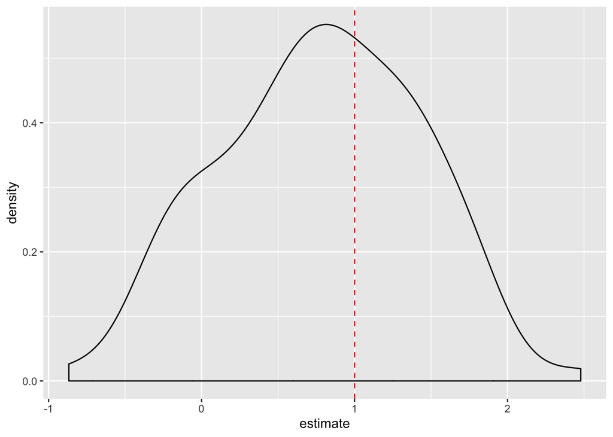

| mean(estimate) | sd(estimate) |
| --- | --- |
| 0.7764945 | 0.6505768 |

The results are better, but somewhat downward biased with higher standard errors

## Double Selection using Rigorous Lasso: `rlassoEffect()`

However, we actually should be using `rlassoEffect()` function from the [`hdm` package](https://github.com/cran/hdm/blob/master/DESCRIPTION).

`rlassoEffect` allows you to use double selection procedure using Rigorous Lasso, which uses theory- and data-driven search for lambda, instead of cross-validation. As it appears, when the end goal is inference, rigorous Lasso is simply better. [see lecture slides]

```r
results_DShdm <- rlassoEffect(
  x = simulated %>%  select(-y, -d) %>%  as.matrix(),
  y = simulated$y,
  d = simulated$d,
  method = "double selection")
summary(results_DShdm)$coefficients
```

```
##    Estimate. Std. Error  t value   Pr(>|t|)
## d1  1.098196  0.4784817 2.295169 0.02172345
```

### The distribution of the DS estimator based on rigorous Lasso

**Exercise:** Do the same exercise now for rlassoEffect function

```r
set.seed(83)
source("./functions/simulate_rlassoDS.R")
# Put your answer here
```

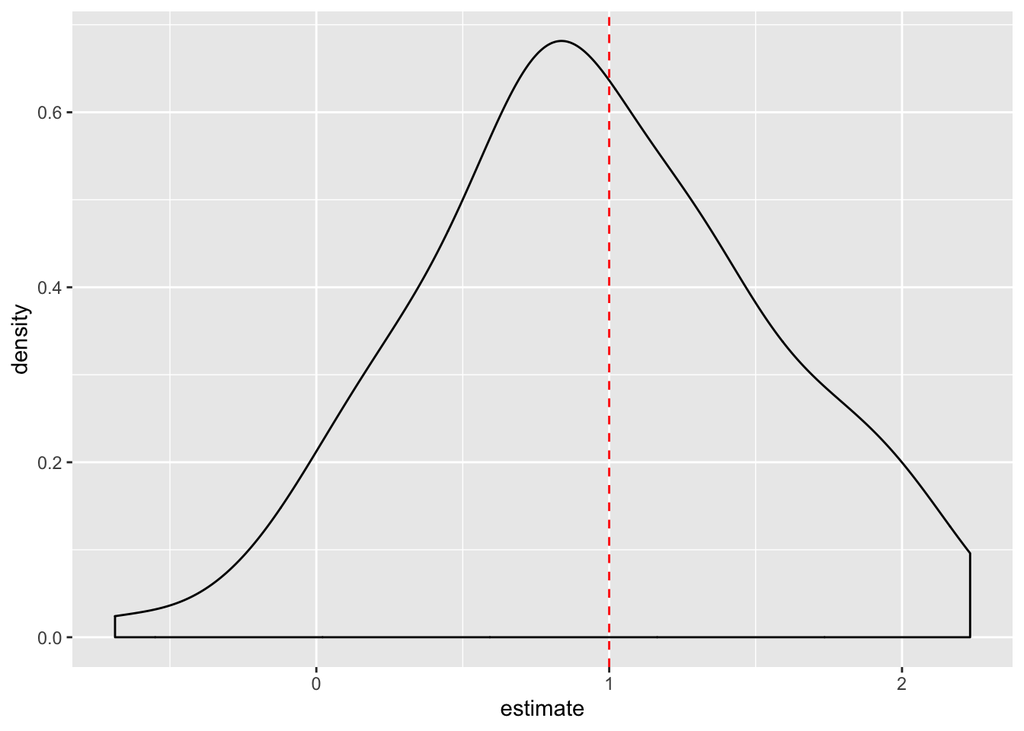

| mean(estimate) | sd(estimate) |
| --- | --- |
| 0.9403243 | 0.5877521 |

It looks pretty good.

Notice, that the double selection using `rlassoEffect()` does its work pretty well. Compare the standard deviation of the estimate: 0.587 vs the true 0.576.

# Final comparison: Naive Lasso vs cross-validated DS vs rigorous DS vs the true distribution

Let’s combine all of the results for different estimators together:

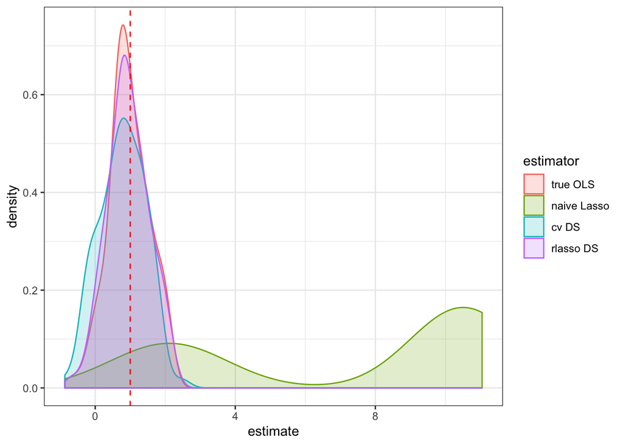

```r
results_all <- bind_rows(
  results_naive     %>%  select(estimate) %>% mutate(estimator = "naive Lasso"),
  results_cvDS      %>%  select(estimate) %>% mutate(estimator = "cv DS"),
  results_rlassoDS  %>%  select(estimate) %>% mutate(estimator = "rlasso DS"),
  results_true      %>%  select(estimate) %>% mutate(estimator = "true OLS"),
) %>%
  mutate(estimator = factor(estimator, levels = c("true OLS", "naive Lasso", "cv DS", "rlasso DS")))

results_all %>%
  ggplot(aes(x = estimate, fill = estimator, color = estimator)) +
    geom_density(alpha = 0.2) +
    geom_vline(xintercept = 1, linetype = "dashed", color = "red") +
  theme_bw()
```

Bottomline: rlasso DS > cv DS. And never use single Lasso for inference

# HOMEWORK: Use simulations to study the behavior of rlassoDS vs cvDS vs trueOLS estimators

Check whether the answers might change as:

1. number of predictors increase (make a grid of different values of `P`)
2. number of variables important for the assignment of treatment decreases/increases (i.e., in our example `d` depended only on `V1`, `V2`, and `V3`). See whether removing/adding more variables to the data-generating process for `d` will change the distributions the estimators. How can we link this to sparsity assumption?
3. the size of the treatment effect lowers or increases (in our example it was 1, does anything change if it drops to 0.1, or increases to 10?).